# **Rapport statistique sur un jeu de données**

YIFEI WANG, M1 MIASHS-C2ES

2020-11-01

## **Description**

- **Sujet : “*French Train stats*” ->** [Source](https://github.com/Da11tura/tidytuesday/tree/master/data/2019/2019-02-26)
- **Packages utilisés**

```r
library(nycflights13)
library(tidyverse)
library(ggthemes)
library(ggplot2)
library(skimr)
library(dplyr)
library(broom)
```

- **Import data original**

```r
tgv <- readr::read_csv("https://raw.githubusercontent.com/rfordatascience/tidytuesday/master/data/2019/2019-02-26/full_trains.csv")
```

- **Description des données**

  Cet ensemble de données présente les annulations et les retards de trains, ainsi que les causes de retard, sur la période de 2015-2018. Il contient un total de 5462 observations et 27 variables.

## **Traiter le tableau**

Tout d’abord, j’ai traité l’ensemble de données original, et j’ai obtenu deux sous-tableaux `tgv_sncf` et `pourquoi_taux`.

- **Sous-tableau 1 : `tgv_sncf`**

```r
tgv %>%
  mutate(nombre_trains = total_num_trips - num_of_canceled_trains,
         taux_retard_departure = num_late_at_departure / nombre_trains * 100,
         taux_retard_arrival = num_arriving_late / nombre_trains * 100) %>%
  select(year, month, nombre_trains, journey_time_avg, total_num_trips, num_of_canceled_trains,
         contains("departure"), contains("departing"), contains("arrival"),
         contains("arriving"),-contains("comment")) -> tgv_sncf

tgv_sncf
```

```
# A tibble: 5,462 x 16
    year month nombre_trains journey_time_avg total_num_trips num_of_canceled…
   <dbl> <dbl>         <dbl>            <dbl>           <dbl>            <dbl>
 1  2017     9           299             85.1             299                0
 2  2017     9           217             47.1             218                1
 3  2017     9           332            116.              333                1
 4  2017     9           480            161.              481                1
 5  2017     9           190            164.              190                0
 6  2017     9           190            129.              191                1
 7  2017     9           208            184.              208                0
 8  2017     9           214            186.              216                2
 9  2017     9           660            121.              661                1
10  2017     9           201             97.4             201                0
# … with 5,452 more rows, and 10 more variables: departure_station <chr>,
#   num_late_at_departure <dbl>, avg_delay_late_at_departure <dbl>,
#   taux_retard_departure <dbl>, avg_delay_all_departing <dbl>,
#   arrival_station <chr>, avg_delay_late_on_arrival <dbl>,
#   taux_retard_arrival <dbl>, num_arriving_late <dbl>,
#   avg_delay_all_arriving <dbl>
```

| Nom de colonnes | Explication |
| --- | --- |
| journey_time_avg | Temps moyen de trajet (minutes) |
| total_num_trips | Nombre total de trains au cours de la période |
| num_late_at_departure | Nombre de trains en retard au départ |
| avg_delay_late_at_departure | Temps moyen (minutes) pour les trains en retard au départ |
| avg_delay_all_departing | Temps moyen (minutes) pour tous les trains au départ |
| num_arriving_late | Nombre de trains arrivant en retard |
| avg_delay_late_on_arrive | Temps moyen (minutes) pour les trains en retard à l’arrivée |
| avg_delay_all_arriving | Délai moyen (minutes) pour tous les trains arrivant |

- **Sous-tableau 2 : `pourquoi_taux`**

```r
tgv %>%
  select(year, month, starts_with("delay_cause_")) %>%
  summarise(external_cause = mean(delay_cause_external_cause, na.rm = T)*100,
            rail_infrastructure = mean(delay_cause_rail_infrastructure, na.rm = T)*100,
            traffic_management = mean(delay_cause_traffic_management, na.rm = T)*100,
            rolling_stock = mean(delay_cause_rolling_stock, na.rm = T)*100,
            station_management = mean(delay_cause_station_management, na.rm = T)*100,
            travelers = mean(delay_cause_travelers, na.rm = T)*100) %>%
  pivot_longer(everything(), names_to = "Raisons", values_to = "taux") %>%
  mutate(label_p = paste(Raisons, '(', round(taux, 2), '%)', sep = ''),
         type = factor(label_p,levels=label_p)) %>%
  arrange(-taux) -> pourquoi_taux

pourquoi_taux
```

```
# A tibble: 6 x 4
  Raisons              taux label_p                    type
  <chr>               <dbl> <chr>                      <fct>
1 external_cause      27.8  external_cause(27.8%)      external_cause(27.8%)
2 rail_infrastructure 25.2  rail_infrastructure(25.18… rail_infrastructure(25.1…
3 traffic_management  18.3  traffic_management(18.31%) traffic_management(18.31…
4 rolling_stock       17.9  rolling_stock(17.88%)      rolling_stock(17.88%)
5 station_management   7.00 station_management(7%)     station_management(7%)
6 travelers            3.73 travelers(3.73%)           travelers(3.73%)
```

1. Ce tableau décrit les causes des retards de trains et leurs pourcentages. Les causes sont divisées en six catégories.
2. Ce sont des explications de causes ：

| Les causes | Explication |
| --- | --- |
| delay_cause_external_cause | Les externes (météo, colis suspects, grève etc) |
| delay_cause_rail_infrastructure | L’infrastructure ferroviaire (travaux) |
| delay_cause_traffic_management | La gestion tarif (intéraction réseaux) |
| delay_cause_rolling_stock | Le matériel roulant |
| delay_cause_station_management | La gestion en gare et réutilisation de matériel |
| delay_cause_travelers | Prise en compte voyageurs (affluence) |

## **QUESTIONS**

### -> Partie 1 : Le taux d’annulation

#### Question 1 : Quelle année est une mauvaise année en termes d’annulation de trains?

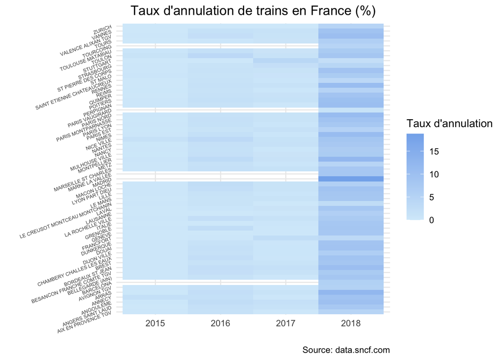

```r
tgv_sncf %>%
  group_by(year, departure_station) %>%
  summarise(sum_annulation = sum(num_of_canceled_trains, na.rm = T), sum_total = sum(total_num_trips, na.rm = T),
    taux_annulation = 100*sum_annulation/sum_total) %>%
  mutate(year = as.factor(year)) %>%
  ggplot(aes(x = year, y = departure_station)) +
  geom_tile(aes(fill = taux_annulation)) +
  labs(x = "", y = "",fill = "Taux d'annulation", title = "Taux d'annulation de trains en France (%)",
       caption  = "Source: data.sncf.com") +
  scale_fill_gradient(low = "#d6ecfa", high = "#84B1ED") +
  theme_minimal() +
  theme(plot.title = element_text(hjust = 0.5),
        axis.text.y=element_text(angle = 20, size = 5))
```

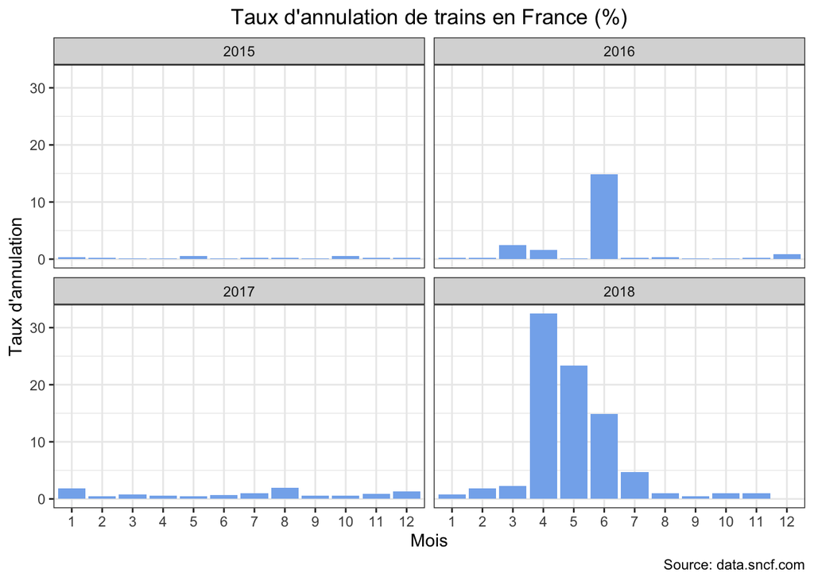

```r
tgv_sncf %>%
  group_by(year, month) %>%
  mutate(taux_annulation = mean(num_of_canceled_trains/total_num_trips*100, na.rm = T),
         month = as.factor(month)) %>%
  ggplot(aes(x = month, y = taux_annulation)) +
  geom_bar(position="dodge", stat="identity", fill = "#84B1ED") +
  theme_bw() +
  facet_wrap(~year) +
  coord_cartesian(xlim = c(1, 12)) +
  labs(x="Mois", y="Taux d'annulation", title = "Taux d'annulation de trains en France (%)",
       caption = "Source: data.sncf.com") +
  theme(plot.title = element_text(hjust = 0.5))
```

- **Réponse** : L’année **2018** a été une mauvaise année pour les annulations de trains. On peut aussi dire que l’augmentation rapide du taux d’annulation de trains est influencée par des facteurs sociaux tels que les grèves.

#### Question 2 : Quelle gare a le taux le plus élevé d’annulation, en 2015-2017?

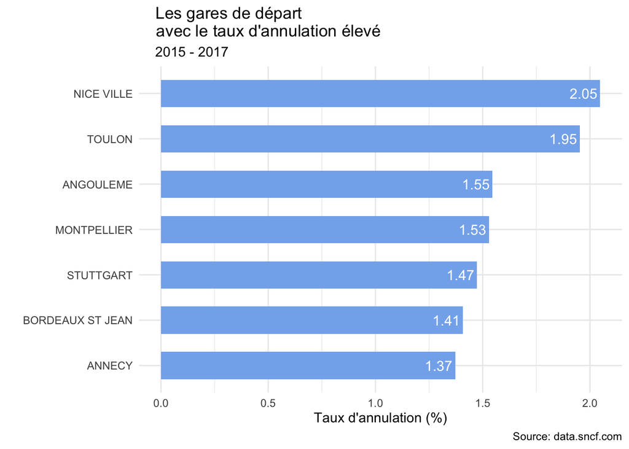

```r
tgv_sncf %>%
  filter(year != 2018) %>%
  group_by(departure_station) %>%
  summarise(sum_annulation = sum(num_of_canceled_trains, na.rm = T), sum_total = sum(total_num_trips, na.rm = T),
            taux_annulation = 100*sum_annulation/sum_total) %>%
  arrange(-taux_annulation) %>%
  slice(1:7) %>%
  ggplot(aes(x = taux_annulation, y = reorder(departure_station,taux_annulation))) +
  geom_bar(position="dodge", stat="identity", fill = "#84B1ED", width = 0.6) +
  geom_text(mapping = aes(label = round(taux_annulation,2)), size = 4,
            vjust = 0.5, hjust = 1.1, colour = "white") +
  labs(x = "Taux d'annulation (%)", y = "", title = "Les gares de départ \n avec le taux d'annulation élevé",
       subtitle = "2015 - 2017", caption  = "Source: data.sncf.com") +
  theme_minimal() +
  theme(plot.title = element_text(hjust = 0.05), plot.subtitle = element_text(hjust = 0.04))
```

- **Réponse** : La gare de **Nice Ville** a enregistré le taux d’annulation le plus élevé, soit 2,05 %.

### -> Partie 2 : Le taux de retard de trains

#### Question 3 : À quel mois le taux de retard de trains à l’arrivée ou au départ est le plus élevé, en 2015-2018?

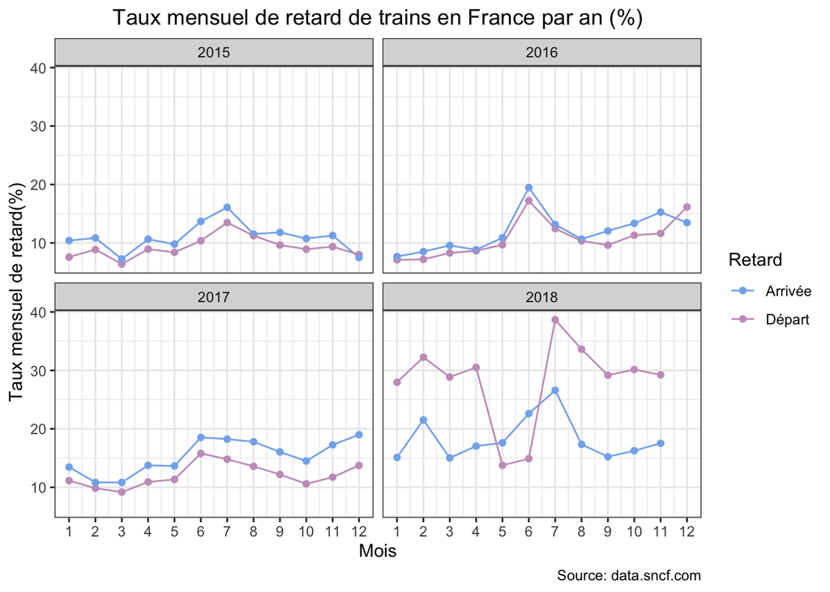

```r
tgv_sncf %>%
  group_by(year, month) %>%
  summarise(moyenne_retard_dep = mean(taux_retard_departure, na.rm = T),
            moyenne_retard_arr = mean(taux_retard_arrival, na.rm = T)) %>%
  select(year, month, moyenne_retard_dep, moyenne_retard_arr) %>%
  pivot_longer(cols = !year & !month, names_to = "retard", values_to = "moyenne_taux") %>%
  ggplot(aes(x = month, y = moyenne_taux, col = retard)) +
  geom_point() +
  geom_line() +
  scale_x_continuous(breaks = seq(0, 12, 1)) +
  facet_wrap(~year) +
  scale_color_manual(values=c("#84B1ED", "#C89EC4"),
                     name="Retard",labels=c("Arrivée", "Départ")) +
  labs(x="Mois", y="Taux mensuel de retard(%)",
       title = "Taux mensuel de retard de trains en France par an (%)",
       caption = "Source: data.sncf.com") +
  theme_bw() +
  theme(plot.title = element_text(hjust = 0.5))
```

- **Réponse** : Le mois **juillet en 2018**, les taux de retard de trains à l’arrivée et au départ sont le plus élevé.

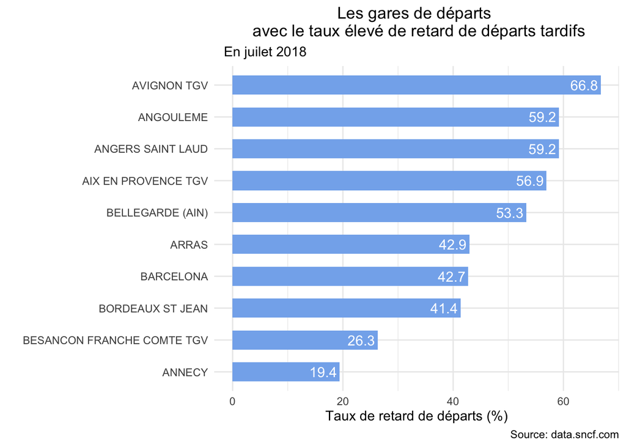

```r
tgv_sncf %>%
  filter(year == 2018 & month == 7) %>%
  group_by(departure_station) %>%
  summarise(mean_dep = mean(taux_retard_departure, na.rm = T)) %>%
  slice(1:10) %>%
  ggplot(aes(x = mean_dep, y = reorder(departure_station,mean_dep))) +
  geom_bar(position="dodge", stat="identity", fill = "#84B1ED", width = 0.6) +
  geom_text(mapping = aes(label = round(mean_dep,1)), size = 4,
            vjust = 0.5, hjust = 1.1, colour = "white") +
  labs(x = "Taux de retard de départs (%)",y = "",
       title = "Les gares de départs \n avec le taux élevé de retard de départs tardifs",
       subtitle = "En juilet 2018", caption  = "Source: data.sncf.com") +
  theme_minimal() +
  theme(plot.title = element_text(hjust = 0.5), plot.subtitle = element_text(hjust = 0.03))
```

### -> Partie 3 : Le temps moyen de retard de trains

#### Question 5 : Quelle gare a le temps le plus long de retard?

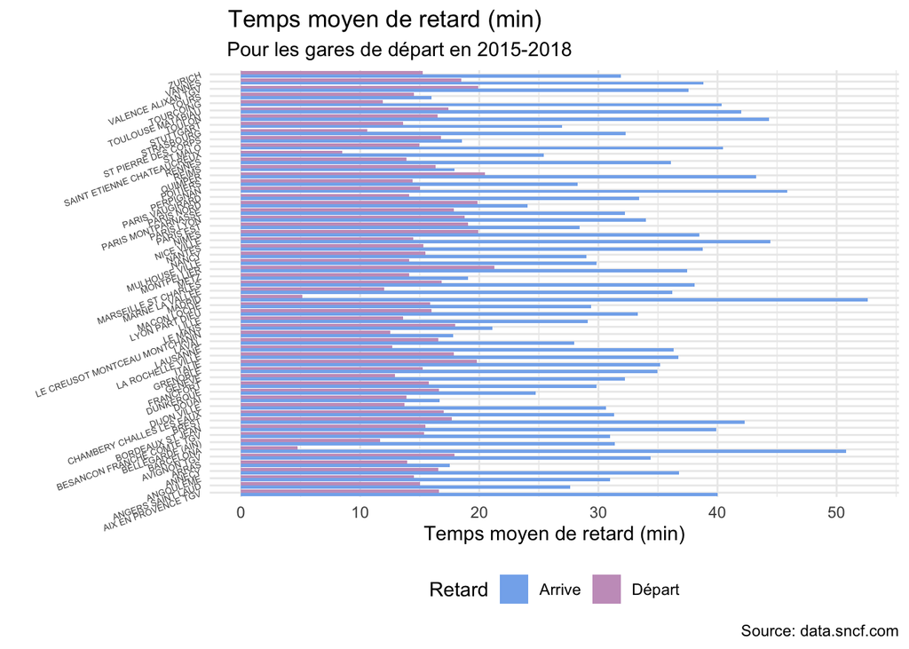

```r
tgv_sncf %>%
  group_by(departure_station) %>%
  summarise(moyenne_retard_dep = mean(avg_delay_late_at_departure, na.rm = T),
            moyenne_retard_arr = mean(avg_delay_late_on_arrival, na.rm = T)) %>%
  select(departure_station, moyenne_retard_dep, moyenne_retard_arr) %>%
  pivot_longer(cols = !departure_station, names_to = "retard", values_to = "moyenne_temps") -> tgv_sncf_temps

tgv_sncf_temps %>%
  ggplot(aes(y = departure_station, x = moyenne_temps, fill = retard)) +
  geom_bar(position="dodge", stat="identity") +
  scale_fill_manual(values=c("#84B1ED", "#C89EC4"),
                     name="Retard",labels=c("Arrive", "Départ")) +
  labs(x="Temps moyen de retard (min)", y="",
       title = "Temps moyen de retard (min)",
       subtitle = "Pour les gares de départ en 2015-2018",
       caption = "Source: data.sncf.com") +
  theme_minimal() +
  theme(plot.title = element_text(hjust = 0.05),
        plot.subtitle = element_text(hjust = 0.05),
        legend.position = "bottom",
        axis.text.y=element_text(angle = 20, size = 5))
```

```r
tgv_sncf_temps %>%
  group_by(retard) %>%
  filter(moyenne_temps == max(moyenne_temps))
```

```
# A tibble: 2 x 3
# Groups:   retard [2]
  departure_station retard             moyenne_temps
  <chr>             <chr>                      <dbl>
1 MADRID            moyenne_retard_arr          52.6
2 MONTPELLIER       moyenne_retard_dep          21.3
```

- **Réponse** : Les deux gares avec les plus longs délais ont été identifiées par la méthode de `filter()`. La gare avec le temps de retard à l’arrivée le plus long est **MADRID**, soit 52,6 minute, et la gare avec le temps de retard au départ le plus long est **MONTPELLIER**, soit 21,3 minute.

#### Question 6 : Quelle est le temps mensuel de retard dans le gare “LYON PART DIEU” en 2017?

[figure not shown]

```r
tgv_sncf %>%
  filter(departure_station == 'LYON PART DIEU' & year == 2017) %>%
  select(month, departure_station, avg_delay_late_at_departure, avg_delay_late_on_arrival) %>%
  group_by(month) %>%
  summarise(moyenne_dep = mean(avg_delay_late_at_departure, na.rm = T),
            moyenne_arr = mean(avg_delay_late_on_arrival, na.rm = T)) %>%
  pivot_longer(cols = !month, names_to = "retard", values_to = "moyenne_temps") %>%
  ggplot(aes(x = month, y = moyenne_temps, col = retard)) +
  geom_point() +
  geom_line() +
  geom_text(aes(label = round(moyenne_temps,2), vjust = -1.3, hjust = +0.4), show_guide = FALSE, size = 2) +
  scale_x_continuous(breaks = seq(0, 12, 1)) +
  scale_color_manual(values=c("#84B1ED", "#77AAAD"),
                     name="Retard",labels=c("Depart", "Arrive")) +
  labs(x="Mois", y="Temps moyen de retard (min)",
       title = "Temps moyen de retard (min) \n LYON PART DIEU",
       subtitle = "en 2017",
       caption = "Source: data.sncf.com") +
  theme_classic()+
  theme(plot.title = element_text(hjust = 0.5), plot.subtitle = element_text(hjust = 0.5))
```

### -> Partie 4 : Les grandes lignes

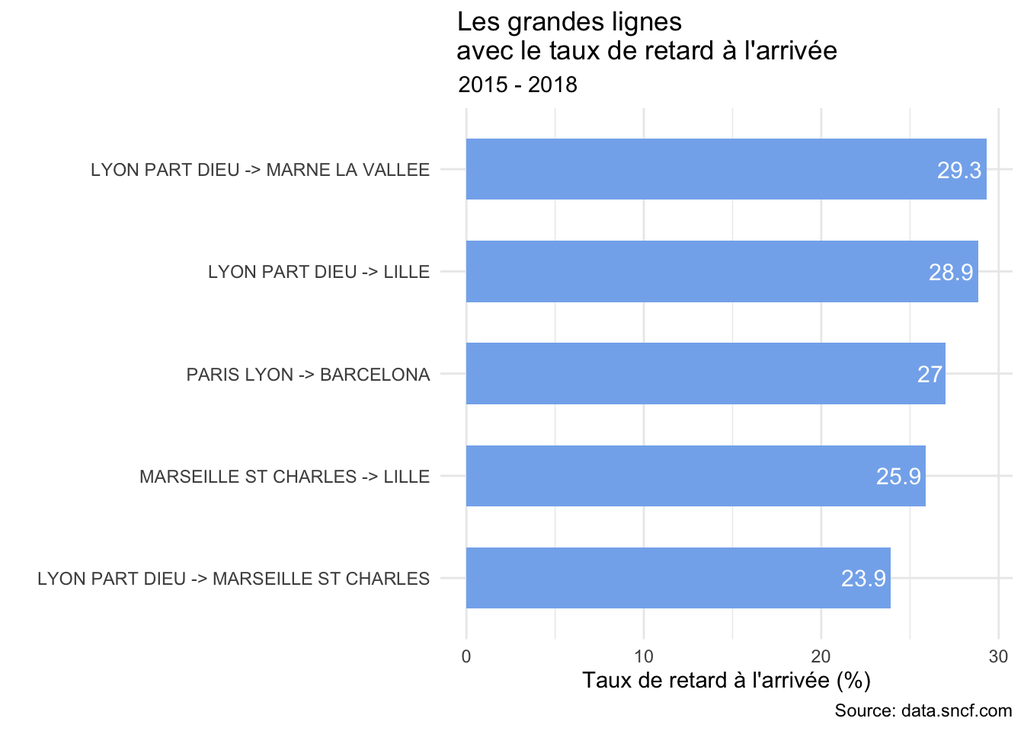

```r
tgv_sncf %>%
  select(departure_station, arrival_station, taux_retard_arrival) %>%
  mutate(Liaisons = paste(departure_station, ' -> ', arrival_station, sep = '')) %>%
  group_by(Liaisons) %>%
  summarise(taux_retard_arrival = mean(taux_retard_arrival, na.rm = T)) %>%
  arrange(-taux_retard_arrival) %>%
  slice(1:5) %>%
  ggplot(aes(x = taux_retard_arrival, y = reorder(Liaisons,taux_retard_arrival))) +
  geom_bar(position="dodge", stat="identity", fill = "#84B1ED", width = 0.6) +
  geom_text(mapping = aes(label = round(taux_retard_arrival, 1)),
            size = 4, vjust = 0.5, hjust = 1.1, colour = "white") +
  labs(x="Taux de retard à l'arrivée (%)", y="",
       title = "Les grandes lignes \n avec le taux de retard à l'arrivée",
       subtitle = "2015 - 2018",
       caption = "Source: data.sncf.com") +
  theme_minimal() +
  theme(plot.title = element_text(hjust = 0.05), plot.subtitle = element_text(hjust = 0.04))
```

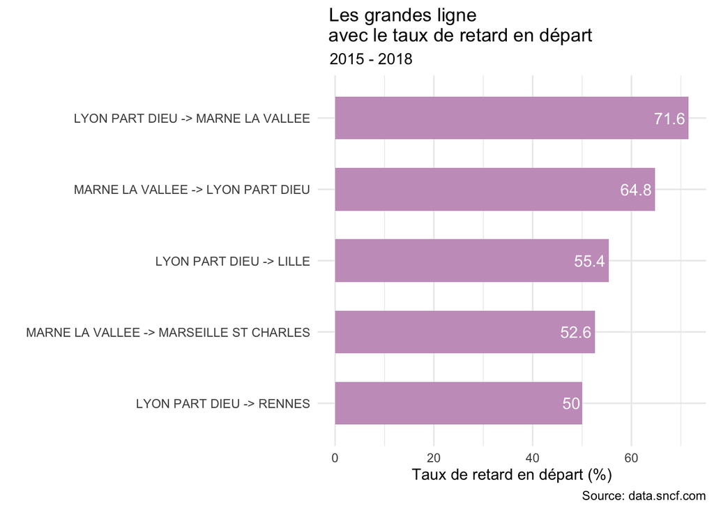

```r
tgv_sncf %>%
  select(departure_station, arrival_station, taux_retard_departure) %>%
  mutate(Liaisons = paste(departure_station, ' -> ', arrival_station, sep = '')) %>%
  group_by(Liaisons) %>%
  summarise(taux_retard_departure = mean(taux_retard_departure, na.rm = T)) %>%
  arrange(-taux_retard_departure) %>%
  slice(1:5) %>%
  ggplot(aes(x = taux_retard_departure, y = reorder(Liaisons,taux_retard_departure))) +
  geom_bar(position="dodge", stat="identity", fill = "#C89EC4", width = 0.6) +
  geom_text(mapping = aes(label = round(taux_retard_departure,1)),
            size = 4, vjust = 0.5, hjust = 1.1, colour = "white") +
  labs(x="Taux de retard en départ (%)", y="",
       title = "Les grandes ligne \n avec le taux de retard en départ",
       subtitle = "2015 - 2018",
       caption = "Source: data.sncf.com") +
  theme_minimal() +
  theme(plot.title = element_text(hjust = 0.05), plot.subtitle = element_text(hjust = 0.04))
```

### -> Partie 5 : Relation

#### Question 9 : Y a-t-il une relation entre le temps de retard et la distance de trajet?

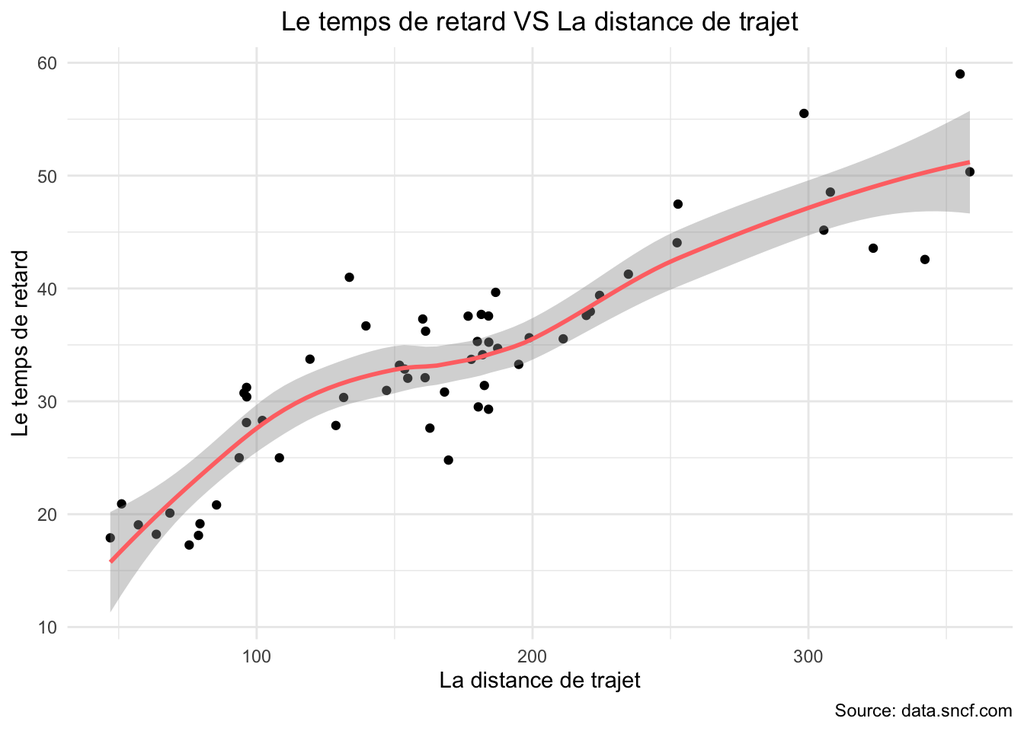

```r
tgv_sncf %>%
  select(year,month,avg_delay_late_at_departure,avg_delay_late_on_arrival,journey_time_avg,arrival_station) %>%
  filter(!is.na(avg_delay_late_at_departure), !is.na(avg_delay_late_on_arrival)) %>%
  group_by(arrival_station) %>%
  summarise(count = n(), dist = mean(journey_time_avg, na.rm = TRUE),
            retard = mean(avg_delay_late_on_arrival,na.rm = TRUE)) -> tgv_sncf_r
tgv_sncf_r %>%
  ggplot(aes(x = dist, y = retard)) +
  geom_point() +
  geom_smooth(col = "#ff7473") +
  theme_minimal() +
  labs(x = "La distance de trajet", y = "Le temps de retard",
       title = "Le temps de retard VS La distance de trajet",
       caption = "Source: data.sncf.com") +
  theme(plot.title = element_text(hjust = 0.5))
```

- **Réponse** : D’après ce graphique, on peut savoir qu’il y a une forte relation entre le temps de retard et la distance de trajet.

```r
lm1=lm(retard~dist,data=tgv_sncf_r)
summary(lm1)
```

```
Call:
lm(formula = retard ~ dist, data = tgv_sncf_r)

Residuals:
    Min      1Q  Median      3Q     Max
-9.0653 -2.5799 -0.3284  2.5892 11.4365

Coefficients:
            Estimate Std. Error t value Pr(>|t|)
(Intercept) 15.41286    1.32079   11.67   <2e-16 ***
dist         0.10585    0.00708   14.95   <2e-16 ***
---
Signif. codes:  0 '***' 0.001 '**' 0.01 '*' 0.05 '.' 0.1 ' ' 1

Residual standard error: 4.187 on 57 degrees of freedom
Multiple R-squared:  0.7968,    Adjusted R-squared:  0.7932
F-statistic: 223.5 on 1 and 57 DF,  p-value: < 2.2e-16
```

- En utilisant la méthode de l’ANOVA, on peut voir que la p-valeur est faible et que le modèle suppoé est valable. Le coefficient de détermination est également de 0,7968, il s’explique que 79,68% de la variance est expliquée par ce modèle.

#### Question 10 : Les causes du retard de TGV ?

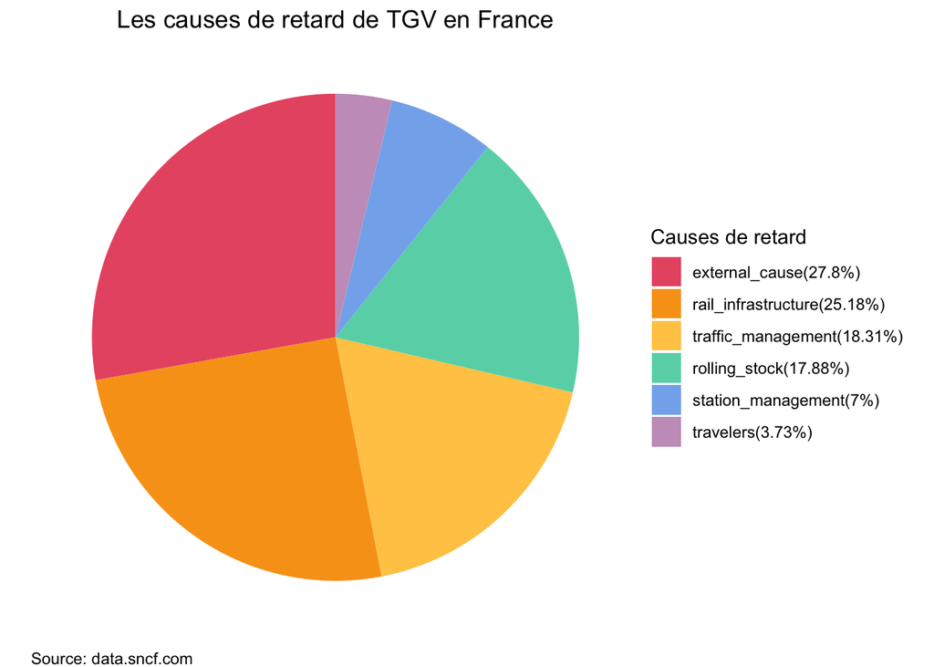

```r
pourquoi_taux %>%
  ggplot(aes(x = 100, weight = taux, fill = type)) +
  geom_bar(width = 1, position = "stack") +
  coord_polar(theta = "y") +
  theme_void() +
  scale_fill_manual(values=c("#e85a71", "#f9a11b", "#ffc952", "#67D5B5", "#84B1ED", "#C89EC4"),
                     name="Causes de retard") +
  labs(title = "Les causes de retard de TGV en France",
       caption = "Source: data.sncf.com") +
  theme(plot.title = element_text(hjust = 0.5),
        plot.caption = element_text(hjust = 0))
```

- **Réponse** : Nous constatons que les facteurs externes ont l’impact le plus important sur les retards des trains soit 27.8%, suivis par l’infrastructure ferroviaire, soit 25.18%.

### **Conclusion**

Sur la base de l’analyse de l’ensemble des données :

- Au cours de la période 2015-2017, la gare de NICE VILLE a connu le taux d’annulation de trains le plus élevé.
- Le taux moyen de retards au départ de la gare de Montpellier et le taux moyen de retard à l’arrivée de la gare de Madrid ont été les plus longs au cours de la période 2015-2018.
- Avec la validation de la méthode ANOVA, nous avons conclu qu’il existe une relation linéaire positive entre le temps de retard et la distance parcourue.
- Les taux de retard et d’annulation de trains en 2018 ont été influencés par des facteurs sociaux, tels que les grèves, qui ont connu une forte augmentation à court terme.